# Count Data Mixed Models - Extensions

# Introduction

## Over-Dispersion

The Poisson model postulates that the mean and the variance of the count data are equal. However, this is a strong assumption that is often not supported by the data. When count data exhibit higher variance than their mean we have [*over-dispersion*](https://en.wikipedia.org/wiki/Overdispersion), and likewise when they exhibit lower variance than their mean we have *under-dispersion*; the former happens more often in practice than the latter.

To account for over-dispersion in count data we can work with the [negative binomial distribution](https://en.wikipedia.org/wiki/Negative_binomial_distribution#Overdispersed_Poisson). This distribution has an extra scale parameter that is used to better capture the variability in the data. More specifically, if we denote by $Y$ the random variable representing the count data, the mean and variance of the negative binomial distribution are:
$$\left \{
\begin{array}{lcl}
E(Y) & = & \mu\\
Var(Y) & = & \mu + \frac{\mu^2}{\phi}.
\end{array}
\right.$$

When $\phi$ is very large the second term in the variance becomes very small, indicating that the mean and the variance are equal. However, when $\phi$ is small, then the variance in the data is larger than the mean $\mu$. The negative binomial mixed effects model is defined along the same lines as the Poisson mixed model. Namely,

1. Conditional on the random effects $b_i$, the responses $y_{ij}$ are independent and have a negative binomial distribution with mean $E(y_{ij} \mid b_i) = \mu_{ij}$ and variance $\mbox{var}(y_{ij} \mid b_i) = \mu_{ij} + \mu_{ij}^2 / \phi$.
2. The conditional mean of $y_{ij}$ depends upon fixed and random effects via the following expression:
   $$\log(\mu_{ij}) = x_{ij}^\top \beta + z_{ij}^\top b_i$$
3. The random effects follow a multivariate normal distribution with mean zero and variance-covariance matrix $D$.

With regard to the interpretation of the coefficients, the model building, and hypothesis testing the same considerations apply as the ones we have seen for dichotomous data.

## Zero-Inflation

Another common problem with count data models, including both Poisson and negative binomial models, is that empirical data often show more zeros than what would be expected under either model. To improve the fit of both models in this situation we can the zero-inflation extension of these models. The zero-inflated Poisson and negative binomial models postulate that there are two *latent* classes of subjects. The subjects in the *always zero* class, and the rest of the subjects for whom the count outcome has a Poisson or negative binomial distribution. Note that in the second class we still have zeros but we can also have positive counts, whereas in the former class we only get zeros. In the context of longitudinal studies it can be that subject switch classes during follow-up.

The zero-inflated model combines two models, a logistic regression model that predicts to which of the two latent classes a subject belongs, with a Poisson or negative binomial model that predicts the outcome for those in the second latent class. A mixed effects zero-inflated model includes in the aforementioned model random effects. We have the option to include random effects only in the Poisson or negative binomial model for the second latent class or also in the logistic regression model for the probability of belonging to the first class.

## Goodness-of-Fit

Residual interpretation for generalized linear mixed models is often problematic. One reason why residuals from these models are harder to interpret is that the expected distribution of the data changes with the fitted values. Re-weighting with the expected variance, as done in Pearson residuals, or using deviance residuals, helps a bit, but does not lead to visually homogeneous residuals even if the model is correctly specified. As a result, standard residual plots, when interpreted in the same way as for linear models, seem to show all kind of problems, such as non-normality, heteroscedasticity, even if the model is correctly specified.

To overcome these problems the [**DHARMa** package](https://cran.r-project.org/package=DHARMa) provides a simulated type of residuals, which for correctly specified models, and irrespective of the type of the model, the residuals are expected to have a flat/uniform distribution. We will use these residuals to evaluate the fit of the models presented above for count data.

# An Example

We will again use the CD4 cell counts from the AIDS dataset to illustrate the extensions discussed above. We first load the required packages and the data from GitHub (**note:** we will also use the [**DHARMa**](https://cran.r-project.org/package=DHARMa) package; if you do not have it installed, you will first need to install it using the `install.packages()` function):

```r
library("GLMMadaptive")
library("splines")
library("DHARMa")

con <- url("https://raw.github.com/drizopoulos/Repeated_Measurements/master/Data.RData")
load(con)
close(con)
```

And the we also create the CD4 cell count variable

```r
aids$CD4count <- aids$CD4 * aids$CD4
```

## Standard Poisson Mixed Model

Based on the previous analysis we have done in Advanced Topic “Count Data 1”, we start with the model have selected there:

```r
fm1 <- mixed_model(CD4count ~ drug * ns(obstime, knots = c(2, 6), B = c(0, 12)),
                   random = ~ ns(obstime, knots = c(2, 6), B = c(0, 12)) || patient,
                   data = aids, family = poisson())
```

We will evaluate the fit of this model using the simulated residuals of the **DHARMa** package. To calculate these residuals for models fitted by the `mixed_model()` function we need the following helper function:

```r
resids_plot <- function (object, y, nsim = 1000,
                         type = c("subject_specific", "mean_subject"),
                         integerResponse = NULL) {
    if (!inherits(object, "MixMod"))
        stop("this function works for 'MixMod' objects.\n")
    type <- match.arg(type)
    if (is.null(integerResponse)) {
        integer_families <- c("binomial", "poisson", "negative binomial",
                              "zero-inflated poisson", "zero-inflated negative binomial",
                              "hurdle poisson", "hurdle negative binomial")
        numeric_families <- c("hurdle log-normal", "beta", "hurdle beta")
        if (object$family$family %in% integer_families) {
            integerResponse <- TRUE
        } else if (object$family$family %in% numeric_families) {
            integerResponse <- FALSE
        } else {
            stop("non build-in family object; you need to specify the 'integerResponse',\n",
                 "\targument indicating whether the outcome variable is integer or not.\n")
        }
    }
    sims <- simulate(object, nsim = nsim, type = type)
    fits <- fitted(object, type = type)
    dharmaRes <- DHARMa::createDHARMa(simulatedResponse = sims, observedResponse = y,
                              fittedPredictedResponse = fits,
                              integerResponse = integerResponse)
    DHARMa:::plot.DHARMa(dharmaRes, quantreg = FALSE)
}
```

In this function we need to specify the model and the outcome variable from the original data. Hence, for the Poisson mixed effects model we use the syntax:

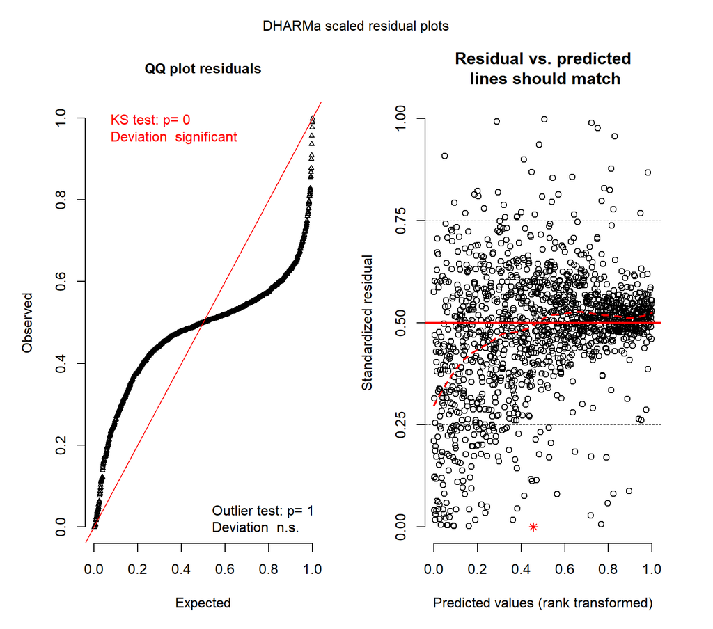

```r
resids_plot(fm1, aids$CD4count)
```

The left panel shows the QQ-plot that evaluates if the distribution of the residuals is uniform, i.e., we have a good fit when all residuals are across the diagonal. The right panel shows the residuals (y-axis) versus predicted values; when the model fits well these should be a random scatter plot that does not show any systematic patterns (the red dashed line should be close to the solid horizontal line at 0.5, and the spread of residuals needs to be the same for all levels of predicted values). We observe that the fit of the Poisson mixed model is not good. Both the distribution of the residuals is far from the uniform, and we also see clear signs of heteroscedasticity.

## Negative Binomial Mixed Model

To account for the over-dispersion we have seen in the residuals plot we will use a negative binomial mixed model. To fit this model we can use exactly the same syntax, and only change the `family` argument to `negative.binomial()`. In the following we do this more quickly by using the `update()` function,

```r
fm2 <- update(fm1, family = negative.binomial())
```

The Poisson mixed model is nested within the negative binomial one. Therefore, we can use a likelihood ratio test to compare the two models using the `anova()` function:

```r
anova(fm1, fm2)
```

```
#>
#>          AIC      BIC  log.Lik    LRT df p.value
#> fm1 13884.57 13934.33 -6930.29
#> fm2 13459.89 13513.79 -6716.94 426.68  1 <0.0001
```

The results suggest that inclusion of the extra over-dispersion parameter improves the fit of the model. Let’s see now if the overall fit is improved by using the simulated residuals again:

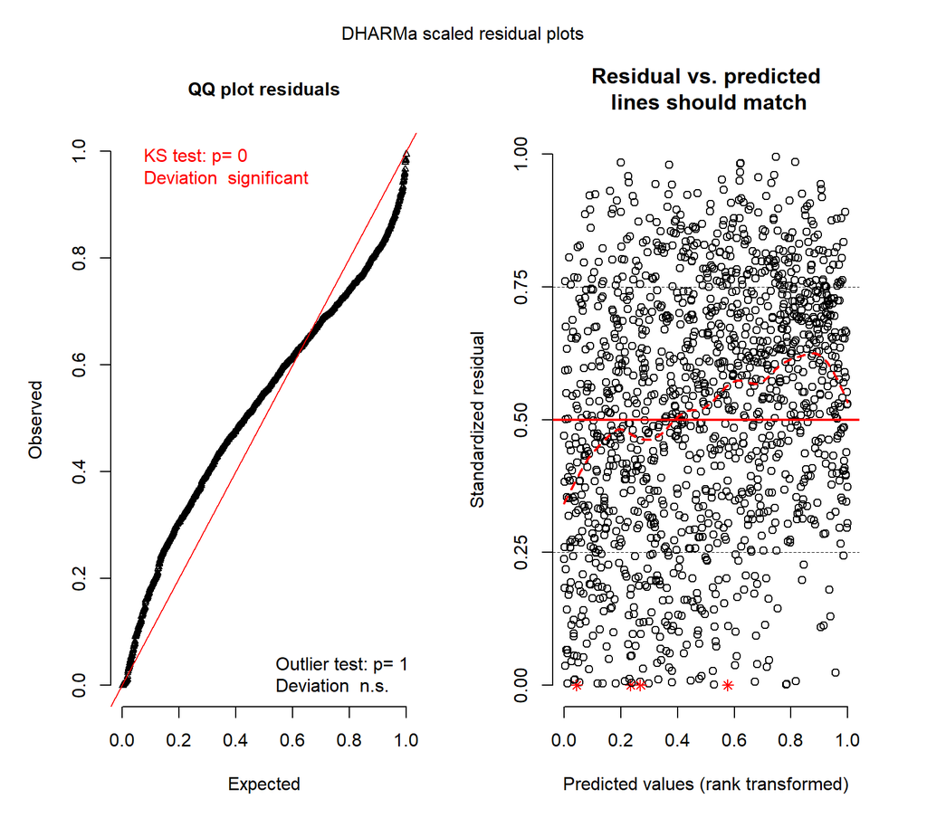

```r
resids_plot(fm2, aids$CD4count)
```

We observe an evident improvement in both the distribution of the residuals and in the scatterplot of the standardized residuals versus predicted values in which we do not observe any alarming systematic trends.

## Zero-Inflated Negative Binomial Mixed Model

We proceed to evaluate whether we have issues with the frequency of zero counts in the data by evaluating if the zero-inflated extension of the negative binomial model improves the fit.

Function `mixed_model()` of the **GLMMadaptive** package can also be used to fit [zero-inflated and two-part mixed effects models](https://drizopoulos.github.io/GLMMadaptive/articles/ZeroInflated_and_TwoPart_Models.html). For both types of models, a suitable `family` object needs to be specified, and also arguments `zi_fixed` and `zi_random` of `mixed_model()` come into play. In these arguments, the user can specify the fixed and random effects `formulas` of the logistic regression for the zero-part (first latent class) of the distribution of the outcome. We should note that the user has the option to leave `zi_random` set to `NULL`, in which case for the zero-part we have a logistic regression with only fixed effects and no random effects.

We continue by fitting a zero-inflated negative binomial mixed model, with only fixed effects in the logistic regression model for the first latent class (i.e., the class of only zeros). This is achieved with the following syntax, where we use the family object `zi.negative.binomial()`:

```r
fm3 <- update(fm2, family = zi.negative.binomial(), zi_fixed = ~ drug + obstime)
```

The standard negative binomial model is nested within the zero-inflated negative binomial one, and therefore we can compare the two using a likelihood ratio test:

```r
anova(fm2, fm3)
```

```
#>
#>          AIC      BIC  log.Lik   LRT df p.value
#> fm2 13459.89 13513.79 -6716.94
#> fm3 13423.43 13489.77 -6695.71 42.46  3 <0.0001
```

```r
fm4 <- update(fm3, zi_random = ~ 1 | patient, nAGQ = 6)
```

We again evaluate if the fit is improved by a likelihood ratio test:

```r
anova(fm3, fm4)
```

```
#>
#>          AIC      BIC  log.Lik  LRT df p.value
#> fm3 13423.43 13489.77 -6695.71
#> fm4 13426.51 13497.00 -6696.26 1.08  1  0.2979
```

The results show that inclusion of the random intercept term does not improve the fit of the logistic regression model for the probability of belonging in the first class. We also produce the simulated residuals plots for our final model

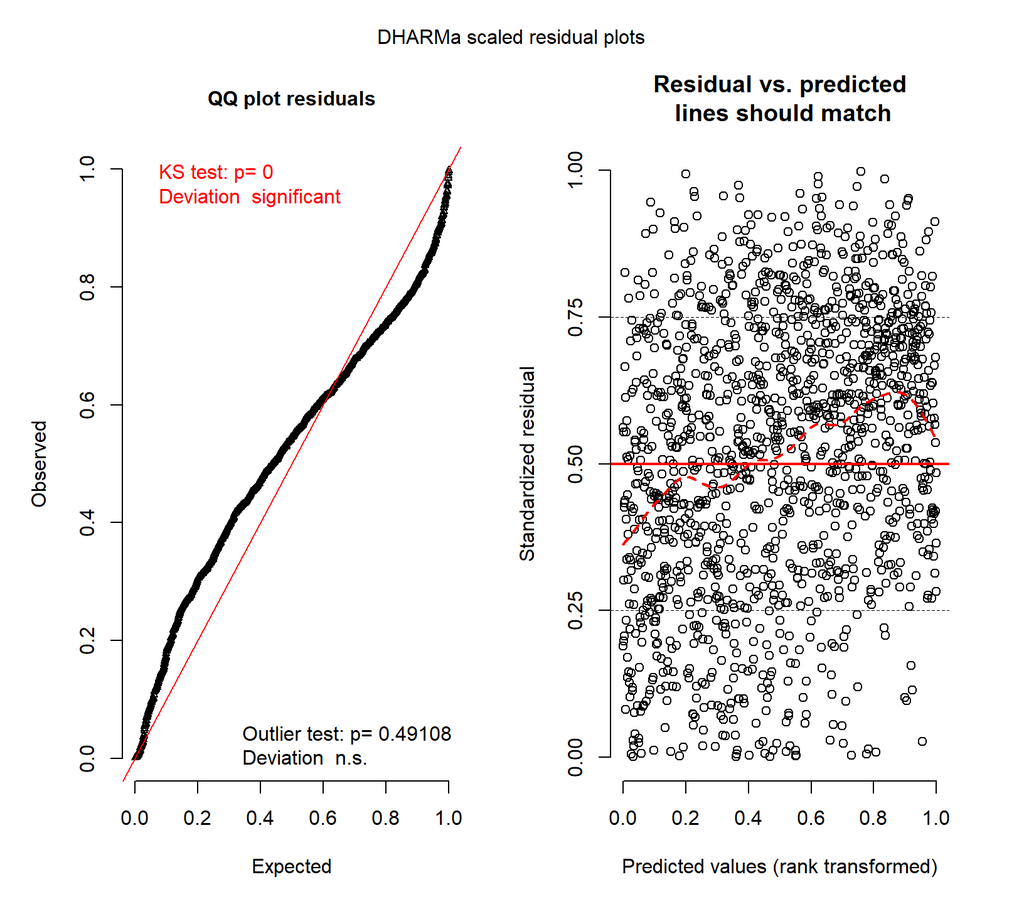

```r
resids_plot(fm3, aids$CD4count)
```

These plots are very similar to ones of model `fm2`. Namely, the fit seems to be acceptable (but not perfect because there is some deviation from the diagonal line in the QQ-plot), with no evident problems of systematic trends.

Finally, we show the effects plot for the expected CD4 cell counts conditional on the random effects from model `fm3`:

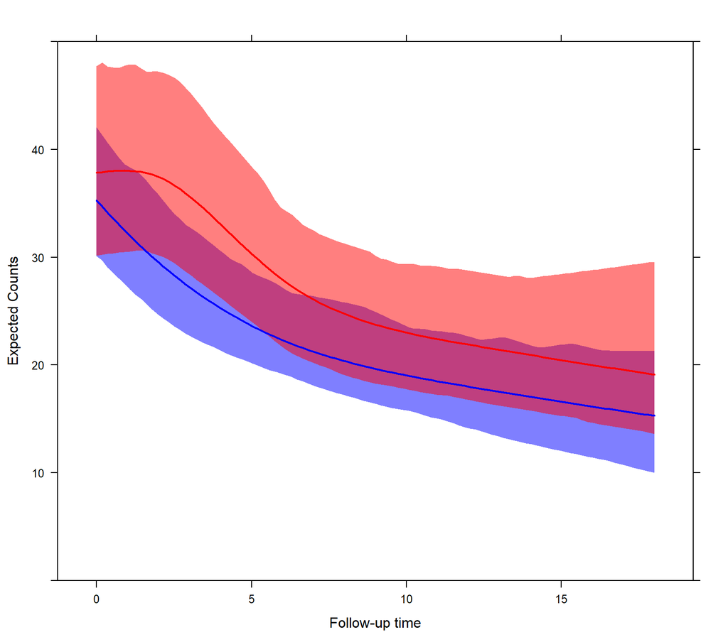

```r
nDF <- with(aids, expand.grid(drug = levels(drug),
                              obstime = seq(0, 18, length.out = 101)))

plot_data <- effectPlotData(fm3, nDF)

my.panel.bands <- function(x, y, upper, lower, fill, col, subscripts, ..., font,
                           fontface) {
    upper <- upper[subscripts]
    lower <- lower[subscripts]
    panel.polygon(c(x, rev(x)), c(upper, rev(lower)), col = fill, border = FALSE, ...)
}

xyplot(exp(pred) ~ obstime, group = drug, data = plot_data,
       upper = exp(plot_data$upp), low = exp(plot_data$low),
       type = "l", col = c("blue", "red"),
       fill = c("#0000FF80", "#FF000080"),
       panel = function (x, y, ...) {
           panel.superpose(x, y, panel.groups = my.panel.bands, ...)
           panel.xyplot(x, y, lwd = 2,  ...)
}, xlab = "Follow-up time", ylab = "Expected Counts", ylim = c(0, 50))
```